# Craycroft, Michaela

## BAN 592 Sports Analytics

### Expected Points Blog

This assignment focuses on expected points and expected points added by analyzing the play by play data of NFL games in the 2019 season. By analyzing these metrics, I will examine the value of Running Backs in the game of football. Lets start by answering the questions “what are expected points and expected points added in football, and what is the significance?”. Expected points (ep) are the expected number of points to be scored next. These values can be 8, 7, 6, 3, 2, or 0 and can be represented both positive or negative. If represented negative, these are the points that can be added by the opponent if the ball is turned over to the opponent during the play. To determine these values we use a statistical definition to calculate the expected points. This equation is as follows:

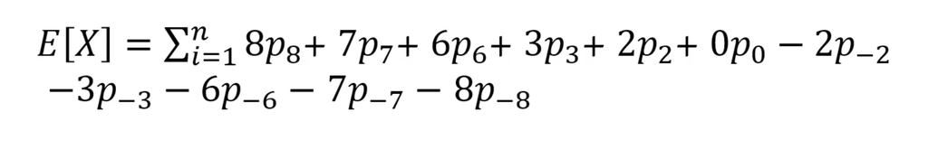

.

We can determine the statistical value of the expected points, but in actuality, probabilities are dependent on the “state” of the game. We can estimate the probabilities by examining historical play-by-play data (such as the dataset I am using), linear regression models, and logistic regression models. Lastly, we can examine expected points added (epa). This metric is used to understand the change in expected points from before a play to after the play. EPA is what is most commonly used in decision-making.

In the below graph, we have the top 10 rushers for the NFL 2019 season. Lamar Jackson, who is actually a QB, had the highest total epa at 72.677 total epa for rushing. He brought in double the amount of epa than the second best rusher in the 2019 season. Patrick Mahomes, another QB, had 36.059 total epa.

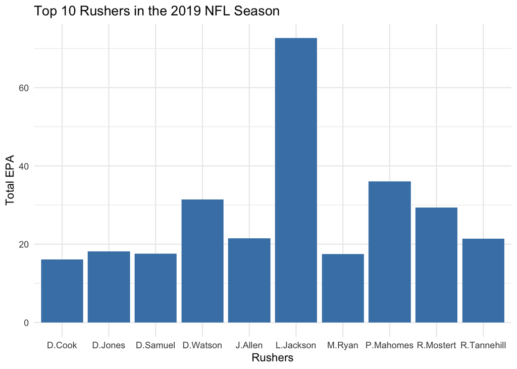

In the table below, we can find the top 10 game performances by rushers according to their total epa for the game. Raheem Mostert had the best game of the season in 2019 when his team, the San Francisco 49ers played the Green Bay Packers. He had a total of 14.058 epa in this single game.

Rushers with the Most EPA in a Game

| Game | Player Name | EPA |
| --- | --- | --- |
| 2019_20_GB_SF | R.Mostert | 14.058 |
| 2019_07_BAL_SEA | L.Jackson | 11.237 |
| 2019_04_JAX_DEN | L.Fournette | 9.959 |
| 2019_17_TEN_HOU | D.Henry | 9.586 |
| 2019_17_LAC_KC | Dam.Williams | 9.477 |
| 2019_03_BAL_KC | M.Ingram | 9.148 |
| 2019_13_WAS_CAR | D.Guice | 9.140 |
| 2019_01_IND_LAC | M.Mack | 8.837 |
| 2019_03_NYG_TB | D.Jones | 8.322 |
| 2019_06_CIN_BAL | L.Jackson | 8.247 |

The next question that I would like to analyze is which rusher had the best run in the 4th down resulting in the most epa? Anthony Levine of the Baltimore Ravens had the best rush in the fourth down with 5.295 epa against the Miami Dolphins in 2019. The fourth down is a nerve-wracking feat for players, as it can make or break a game. Oftentimes, fourth downs can result in negative expected points by the team not scoring and bad decision making by the coach. When points like Anthony Levine’s epa are made, it is impressive.

Rushers with the most EPA in the Fourth Down

| Game | Player Name | Down | EPA |
| --- | --- | --- | --- |
| 2019_01_BAL_MIA | A.Levine | 4 | 5.295 |
| 2019_03_NYG_TB | D.Jones | 4 | 4.425 |
| 2019_21_SF_KC | Dam.Williams | 4 | 4.109 |
| 2019_13_MIN_SEA | T.Homer | 4 | 4.096 |
| 2019_01_HOU_NO | D.Watson | 4 | 4.095 |
| 2019_07_BAL_SEA | L.Jackson | 4 | 3.985 |
| 2019_05_ARI_CIN | K.Murray | 4 | 3.944 |
| 2019_13_GB_NYG | D.Jones | 4 | 3.891 |
| 2019_10_MIN_DAL | D.Cook | 4 | 3.801 |
| 2019_15_SEA_CAR | C.Carson | 4 | 3.674 |

Another visualization for better understanding of the distribution of EPA between the players in the fourth down of the given game. While you may have missed it in the table, the graph shows that Daniel Jones of the New York Giants actually had two of the top 10 rushes in the fourth down for the year of 2019. You can see this more clearly in the graph below.

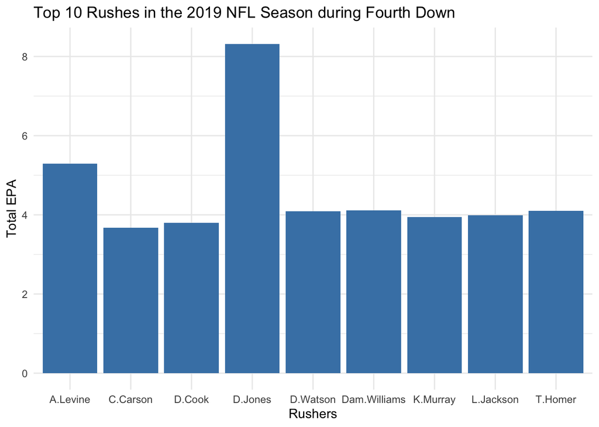